# Zotero group ECA

Published

25 November 2026

Zotero data of 25 November 2026 · IPBES Literature Report 0.7.0 · [source code on GitHub](https://github.com/IPBES-Data/IPBES.LiteratureReport)

This report shows the state of the Zotero group **ECA** ([open the group in Zotero](https://www.zotero.org/groups/2345951)). It gives an overview of the literature in the group, and lists the items which should be corrected.

Each item in the lists can be opened in the Zotero **web** library or in the Zotero **app** on your computer, so that it can be corrected directly. Corrected items disappear from the lists the next time the report is updated. Some checks compare the items with [OpenAlex](https://openalex.org), an open catalogue of scholarly publications.

## Summary

| Status | Check | Items |
| --- | --- | --- |
| ● OK | Retracted publications | 0 |
| ● Please fix | DOI points to a different publication | 19 |
| ● Please fix | Items which are in the group more than once | 40 |
| ● Please fix | DOI field with an invalid DOI | 10 |
| ● Please fix | DOI which does not exist | 6 |
| ● OK | DOI field with a link or prefix instead of the DOI | 0 |
| ● Please check | ISSN not in the standard form | 3 |
| ● Please check | DOI in the wrong field | 5 |
| ● Please check | DOI not found in OpenAlex | 61 |
| ● Please check | Missing or unusual publication year | 14 |
| ● Please check | Empty journal, volume, issue or pages, found in OpenAlex | 31 |
| ● Please check | Language not given as a language code | 1 |
| ● OK | Language differs from OpenAlex | 0 |
| ● For information | No language | 4220 |
| ● Please check | Items without DOI, ISBN, ISSN or URL | 620 |
| ● Please check | Items without DOI, for which a DOI was found | 40 |
| ● OK | OpenAlex ID in Extra not valid | 0 |
| ● For information | Items without their OpenAlex ID in Extra | 2857 |
| ● OK | Items without tags | 0 |

**Please fix**: these items contain errors. **Please check**: these items may need a correction. **For information**: no action needed unless the group uses this, e.g. tags.

## Items to fix

The lists are sorted by importance. Use the search field above a list to find an item. **web** opens the item in the Zotero web library, **app** in the Zotero app.

### Retracted publications

These publications have been retracted. Check whether they should still be cited, and mark or remove them in Zotero.

**✔ Nothing to fix.**

### DOI points to a different publication

The DOI of these items leads to a publication with a different title or year. Usually the DOI is wrong: open the DOI to see where it leads, and correct it in Zotero. If the titles match and only the year differs, the DOI is probably right and the date in Zotero wrong (unless it is a reprint or another edition): correct the date instead. Differences of one year (e.g. published online before print) are not listed.

If the DOI is right although title or year differ (e.g. a book chapter with the DOI of the whole book, or a wrong year in OpenAlex), add the line `DOI checked: correct` to Extra: the item is then no longer listed (the Zotero plugin offers this as “Keep as it is”).

Not listed here: items whose titles differ only by a subtitle missing on one side (OpenAlex often has the title without the part after the colon). They are most likely right; the Zotero plugin lists them separately.

| Open in Zotero | Title in Zotero | Year in Zotero | The DOI leads to | Its year | DOI |
| --- | --- | --- | --- | --- | --- |
| <a href="https://www.zotero.org/groups/2345951/items/UZR79HSA" target="_blank">web</a> &middot; <a href="zotero://select/groups/2345951/items/UZR79HSA">app</a> | To integrate or to segregate: balancing commodity production and biodiversity conservation in European forests | 2016 | To integrate or to segregate: balancing commodity production and biodiversity conservation in European forests | 2013 | <a href="https://doi.org/10.7892/boris.43136" target="_blank">10.7892/boris.43136</a> |
| <a href="https://www.zotero.org/groups/2345951/items/MVN7CWQI" target="_blank">web</a> &middot; <a href="zotero://select/groups/2345951/items/MVN7CWQI">app</a> | The Politics of Scale in Environmental Assessments | 2006 | The Politics of Scale in Environmental Assessments | 2013 | <a href="https://doi.org/10.2307/jj.41003539.7" target="_blank">10.2307/jj.41003539.7</a> |
| <a href="https://www.zotero.org/groups/2345951/items/UHGKKED3" target="_blank">web</a> &middot; <a href="zotero://select/groups/2345951/items/UHGKKED3">app</a> | The dehesa: an agrosilvopastoral system of the mediterranean region with special reference to the Sierra Morena area of Spain | 1991 | The dehesa: an agrosilvopastoral system of the Mediterranean region with special reference to the Sierra Morena area of Spain | 1988 | <a href="https://doi.org/10.1007/bf02220110" target="_blank">10.1007/bf02220110</a> |
| <a href="https://www.zotero.org/groups/2345951/items/SGHVXINL" target="_blank">web</a> &middot; <a href="zotero://select/groups/2345951/items/SGHVXINL">app</a> | Spatial planning and environmental assessments | 2010 | Spatial planning and environmental assessments | 2012 | <a href="https://doi.org/10.4324/9780203124307-18" target="_blank">10.4324/9780203124307-18</a> |
| <a href="https://www.zotero.org/groups/2345951/items/9NMZXT4G" target="_blank">web</a> &middot; <a href="zotero://select/groups/2345951/items/9NMZXT4G">app</a> | The biology of peatlands | 2013 | The Biology of Peatlands | 2006 | <a href="https://doi.org/10.1093/acprof:osobl/9780199602995.001.0001" target="_blank">10.1093/acprof:osobl/9780199602995.001.0001</a> |
| <a href="https://www.zotero.org/groups/2345951/items/2FT5Z4E5" target="_blank">web</a> &middot; <a href="zotero://select/groups/2345951/items/2FT5Z4E5">app</a> | Scavenging by vertebrates: behavioral, ecological, and evolutionary perspectives on an important energy transfer in terrestrial ecosystems | 2014 | Scavenging by vertebrates: behavioral, ecological, and evolutionary perspectives on an important energy transfer pathway in terrestrial ecosystems | 2003 | <a href="https://doi.org/10.1034/j.1600-0706.2003.12378.x" target="_blank">10.1034/j.1600-0706.2003.12378.x</a> |
| <a href="https://www.zotero.org/groups/2345951/items/CYJ6AUQU" target="_blank">web</a> &middot; <a href="zotero://select/groups/2345951/items/CYJ6AUQU">app</a> | Forest Certification as a Global Civil Society Regulatory Institution | 2003 | Forest certification as a global civil society regulatory institution. | 2022 | <a href="https://doi.org/10.34800/fsc-international887" target="_blank">10.34800/fsc-international887</a> |
| <a href="https://www.zotero.org/groups/2345951/items/7Z2KPABS" target="_blank">web</a> &middot; <a href="zotero://select/groups/2345951/items/7Z2KPABS">app</a> | Biodiversity governance: Adjusting local costs and global benefits | 2008 | Biodiversity Governance: Adjusting Local Costs and Global Benefits | 2013 | <a href="https://doi.org/10.4324/9781849775984-18" target="_blank">10.4324/9781849775984-18</a> |
| <a href="https://www.zotero.org/groups/2345951/items/8EESIMMD" target="_blank">web</a> &middot; <a href="zotero://select/groups/2345951/items/8EESIMMD">app</a> | Pusa caspica. The IUCN Red List of Threatened Species 2016: e.T41669A45230700 | 2015 | Pusa caspica: Goodman, S. & Dmitrieva, L. | 2015 | <a href="https://doi.org/10.2305/iucn.uk.2016-1.rlts.t41669a45230700.en" target="_blank">10.2305/iucn.uk.2016-1.rlts.t41669a45230700.en</a> |
| <a href="https://www.zotero.org/groups/2345951/items/ZBITZSVR" target="_blank">web</a> &middot; <a href="zotero://select/groups/2345951/items/ZBITZSVR">app</a> | Exploring the links: Human well-being, poverty, and ecosystem services | 2004 | The United Nations Environment Programme and IYM2002 | 2002 | <a href="https://doi.org/10.1659/0276-4741(2002)022[0390:tunepa]2.0.co;2" target="_blank">10.1659/0276-4741(2002)022[0390:tunepa]2.0.co;2</a> |

[output cut: 9 more lines]

### Items which are in the group more than once

These items are in the group more than once, with the same DOI, or with the same title, year and first author. Keep one copy and merge or delete the others, e.g. with *Duplicate Items* in the Zotero app.

| Open in Zotero | Title | Copies |
| --- | --- | --- |
| <a href="https://www.zotero.org/groups/2345951/items/PXVMHJ6K" target="_blank">web</a> &middot; <a href="zotero://select/groups/2345951/items/PXVMHJ6K">app</a><br><a href="https://www.zotero.org/group… | Mapping and assessment of ecosystems and their services: indicators for ecosystem assessments under action 5 of the EU biodiversity strategy to 2020: 2nd report - final, February 2014 | 2 |
| <a href="https://www.zotero.org/groups/2345951/items/S2YG4LHA" target="_blank">web</a> &middot; <a href="zotero://select/groups/2345951/items/S2YG4LHA">app</a><br><a href="https://www.zotero.org/group… | No saturation in the accumulation of alien species worldwide | 2 |
| <a href="https://www.zotero.org/groups/2345951/items/RALBZMTF" target="_blank">web</a> &middot; <a href="zotero://select/groups/2345951/items/RALBZMTF">app</a><br><a href="https://www.zotero.org/group… | Will climate change promote future invasions? | 2 |
| <a href="https://www.zotero.org/groups/2345951/items/WPJU2KK7" target="_blank">web</a> &middot; <a href="zotero://select/groups/2345951/items/WPJU2KK7">app</a><br><a href="https://www.zotero.org/group… | Vegetation of the Pamir (Tajikistan): Land Use and Desertification Problems | 2 |
| <a href="https://www.zotero.org/groups/2345951/items/SUGH4SGD" target="_blank">web</a> &middot; <a href="zotero://select/groups/2345951/items/SUGH4SGD">app</a><br><a href="https://www.zotero.org/group… | Response of arctic predator guilds to collapsing lemming cycles | 2 |
| <a href="https://www.zotero.org/groups/2345951/items/YNZLI2MT" target="_blank">web</a> &middot; <a href="zotero://select/groups/2345951/items/YNZLI2MT">app</a><br><a href="https://www.zotero.org/group… | Rapid land use change after socio-economic disturbances: the collapse of the Soviet Union versus Chernobyl | 2 |
| <a href="https://www.zotero.org/groups/2345951/items/8LV6AEHJ" target="_blank">web</a> &middot; <a href="zotero://select/groups/2345951/items/8LV6AEHJ">app</a><br><a href="https://www.zotero.org/group… | Combining biodiversity modeling with political and economic development scenarios for 25 EU countries | 2 |
| <a href="https://www.zotero.org/groups/2345951/items/D4DLX5T8" target="_blank">web</a> &middot; <a href="zotero://select/groups/2345951/items/D4DLX5T8">app</a><br><a href="https://www.zotero.org/group… | Potential analysis for further nature conservation in Azerbaijan: A spatial and political investment strategy | 2 |
| <a href="https://www.zotero.org/groups/2345951/items/VVBJK9E8" target="_blank">web</a> &middot; <a href="zotero://select/groups/2345951/items/VVBJK9E8">app</a><br><a href="https://www.zotero.org/group… | The importance and benefits of species | 2 |
| <a href="https://www.zotero.org/groups/2345951/items/HBEHPW3D" target="_blank">web</a> &middot; <a href="zotero://select/groups/2345951/items/HBEHPW3D">app</a><br><a href="https://www.zotero.org/group… | Manifestations and underlying drivers of agricultural land use change in Europe | 2 |

[output cut: 21 more lines]

### DOI field with an invalid DOI

The DOI field of these items contains something which is not a valid DOI. Correct or remove it.

| Open in Zotero | Title | Content of the DOI field |
| --- | --- | --- |
| <a href="https://www.zotero.org/groups/2345951/items/4HFNA4BU" target="_blank">web</a> &middot; <a href="zotero://select/groups/2345951/items/4HFNA4BU">app</a> | Nature and the Life Course : Pathways from Childhood Nature to Adult Environmentalism | Available online: www.colorado.edu/journals/cye |
| <a href="https://www.zotero.org/groups/2345951/items/S9FKHH8U" target="_blank">web</a> &middot; <a href="zotero://select/groups/2345951/items/S9FKHH8U">app</a> | Participatory scenario planning for protected areas management under the ecosystem services framework: the Doñana social-ecological system in | 23 |
| <a href="https://www.zotero.org/groups/2345951/items/8C6RDHPN" target="_blank">web</a> &middot; <a href="zotero://select/groups/2345951/items/8C6RDHPN">app</a> | Communication from the Commission to the European Parliament, the Council, the Economic and Social Committee and the Commettee of the Regions - Our life insurance, our natural capital: an EU biodivers… | COM(2011) 244 fina |
| <a href="https://www.zotero.org/groups/2345951/items/5NI4RSR3" target="_blank">web</a> &middot; <a href="zotero://select/groups/2345951/items/5NI4RSR3">app</a> | Human Development Report 2015. Work for Human Development | ISBN: 978-92-1-126398-5 |
| <a href="https://www.zotero.org/groups/2345951/items/WLUNBNQ9" target="_blank">web</a> &middot; <a href="zotero://select/groups/2345951/items/WLUNBNQ9">app</a> | Ecosystem Health of the Baltic Sea 2003-2007 | 2036 |
| <a href="https://www.zotero.org/groups/2345951/items/XZ6MW22W" target="_blank">web</a> &middot; <a href="zotero://select/groups/2345951/items/XZ6MW22W">app</a> | DIRECTIVE 2006/118/EC OF THE EUROPEAN PARLIAMENT AND OF THE COUNCIL on the protection of groundwater against pollution and deterioration | 2004R0726 - v.7 of 05.06.2013 |
| <a href="https://www.zotero.org/groups/2345951/items/7IJQGZMM" target="_blank">web</a> &middot; <a href="zotero://select/groups/2345951/items/7IJQGZMM">app</a> | European landscape convention | http://conventions.coe.int/Treaty/en/Treaties/Html/176.htm |
| <a href="https://www.zotero.org/groups/2345951/items/IXDDSVDW" target="_blank">web</a> &middot; <a href="zotero://select/groups/2345951/items/IXDDSVDW">app</a> | Participatory scenario planning for protected areas management under the ecosystem services framework: the Donana social-ecological system in southwestern Spain | 23 |
| <a href="https://www.zotero.org/groups/2345951/items/JEGKGHXV" target="_blank">web</a> &middot; <a href="zotero://select/groups/2345951/items/JEGKGHXV">app</a> | Agricultural sector, rural environment and biodiversity in the Central and Eastern European EU member states | https://doi.org/10.21120/ |
| <a href="https://www.zotero.org/groups/2345951/items/IUZXSIMY" target="_blank">web</a> &middot; <a href="zotero://select/groups/2345951/items/IUZXSIMY">app</a> | Changes in nature's balance sheet: Model-based estimates of future worldwide ecosystem services | Artn 19 |

### DOI which does not exist

The DOI of these items does not exist at doi.org: usually a typo, a shortened DOI, or a DOI with extra characters at the end. Where the DOI without these characters exists, it is given as suggestion. Otherwise find the right DOI, or remove it (then the search by title in OpenAlex can offer one).

| Open in Zotero | Title | Content of the DOI field | Suggestion |
| --- | --- | --- | --- |
| <a href="https://www.zotero.org/groups/2345951/items/HBMB48VY" target="_blank">web</a> &middot; <a href="zotero://select/groups/2345951/items/HBMB48VY">app</a> | Travel Demand Management and Road User Pricing: Success, Failure and Feasibility | 10.4324/9781315549743-1/travel-demand-management-road-user-pricing-success-failure-feasibility-wafaa-saleh-gerd-sammer |  |
| <a href="https://www.zotero.org/groups/2345951/items/BZGB6DR4" target="_blank">web</a> &middot; <a href="zotero://select/groups/2345951/items/BZGB6DR4">app</a> | The impact of EU consumption on deforestation | 10.2779/822269 |  |
| <a href="https://www.zotero.org/groups/2345951/items/IZ8GHYEZ" target="_blank">web</a> &middot; <a href="zotero://select/groups/2345951/items/IZ8GHYEZ">app</a> | Armillaria ectypa. The IUCN Red List of Threatened Species 2015: e.T75097245A75098379 | 10.2305/iucn.uk.2015- |  |
| <a href="https://www.zotero.org/groups/2345951/items/ZK2Y6HV3" target="_blank">web</a> &middot; <a href="zotero://select/groups/2345951/items/ZK2Y6HV3">app</a> | International Law and 'Relative Normativity' | 10.1093/he/9780199654673.001.0001/he-9780199654673-chapter-6 |  |
| <a href="https://www.zotero.org/groups/2345951/items/QDYKZGVU" target="_blank">web</a> &middot; <a href="zotero://select/groups/2345951/items/QDYKZGVU">app</a> | Agroforestry for Landscape Restoration and Livelihood Development in Central Asia | 10.5716/WP14143 |  |
| <a href="https://www.zotero.org/groups/2345951/items/YUW96SZC" target="_blank">web</a> &middot; <a href="zotero://select/groups/2345951/items/YUW96SZC">app</a> | Quantifying the contribution of organisms to the provison of ecosystem services | 10.1025/bio.2009.59.3.7 |  |

### DOI field with a link or prefix instead of the DOI

The DOI field of these items contains the DOI as a link (`https://doi.org/…`) or with a prefix (`DOI …`). Citation styles add the link themselves, so it would appear twice. Replace it with the DOI only.

**✔ Nothing to fix.**

### ISSN not in the standard form

The ISSN field of these items is not in the standard form `1234-567X` (several separated by “,”), or contains something which is not a valid ISSN, e.g. an ISBN.

| Open in Zotero | Title | Content of the ISSN field | Standard form | Not a valid ISSN |
| --- | --- | --- | --- | --- |
| <a href="https://www.zotero.org/groups/2345951/items/9A9D5GG3" target="_blank">web</a> &middot; <a href="zotero://select/groups/2345951/items/9A9D5GG3">app</a> | Invertebrate communities in acid streams | 0521334357 | NA | 0521334357 |
| <a href="https://www.zotero.org/groups/2345951/items/4SYWDBAC" target="_blank">web</a> &middot; <a href="zotero://select/groups/2345951/items/4SYWDBAC">app</a> | Hotspots of uncertainty in land use and land cover change projections: a global scale model comparison | 1972952943 | NA | 1972952943 |
| <a href="https://www.zotero.org/groups/2345951/items/KKVRCNRU" target="_blank">web</a> &middot; <a href="zotero://select/groups/2345951/items/KKVRCNRU">app</a> | Carbon accumulation in European forests | 425 - 429 | NA | 425, -, 429 |

### DOI in the wrong field

These items have no DOI in the DOI field, but a DOI in the URL or Extra field. Copy the DOI into the DOI field.

| Open in Zotero | Title | DOI in URL | DOI in Extra |
| --- | --- | --- | --- |
| <a href="https://www.zotero.org/groups/2345951/items/YK5ZVUEA" target="_blank">web</a> &middot; <a href="zotero://select/groups/2345951/items/YK5ZVUEA">app</a> | The Economics of Land Degradation in Russia | <a href="https://doi.org/10.1007/978-3-319-19168-3" target="_blank">10.1007/978-3-319-19168-3</a> |  |
| <a href="https://www.zotero.org/groups/2345951/items/LU3THW4L" target="_blank">web</a> &middot; <a href="zotero://select/groups/2345951/items/LU3THW4L">app</a> | The Evolution of Stakeholders' Participation in a Process of Forest Policy Reform in Kyrgyz Republic (reviewed paper) | <a href="https://doi.org/10.3188/szf.2005.0385" target="_blank">10.3188/szf.2005.0385</a> |  |
| <a href="https://www.zotero.org/groups/2345951/items/GQJEK5CF" target="_blank">web</a> &middot; <a href="zotero://select/groups/2345951/items/GQJEK5CF">app</a> | A general model for biodiversity and its value | <a href="https://doi.org/10.4324/9781315530215.ch5" target="_blank">10.4324/9781315530215.ch5</a> |  |
| <a href="https://www.zotero.org/groups/2345951/items/PSRVWYUD" target="_blank">web</a> &middot; <a href="zotero://select/groups/2345951/items/PSRVWYUD">app</a> | The IUCN Red List of threatened Species. 2016 | <a href="https://doi.org/10.2305/iucn.uk.2016-3.rlts.t22697599a90354089.en" target="_blank">10.2305/iucn.uk.2016-3.rlts.t22697599a90354089.en</a> |  |
| <a href="https://www.zotero.org/groups/2345951/items/6ZAACUMQ" target="_blank">web</a> &middot; <a href="zotero://select/groups/2345951/items/6ZAACUMQ">app</a> | The Sources of International Law | <a href="https://doi.org/10.1093/he/9780199654673.001.0001/he-9780199654673" target="_blank">10.1093/he/9780199654673.001.0001/he-9780199654673</a> |  |

### DOI not found in OpenAlex

These DOIs exist, but were not found in OpenAlex (DOIs which do not exist are listed above). If the DOI leads to the right publication, the publication is simply not (yet) in OpenAlex and nothing needs to be done.

| Open in Zotero | Title | DOI |
| --- | --- | --- |
| <a href="https://www.zotero.org/groups/2345951/items/I72BCIA2" target="_blank">web</a> &middot; <a href="zotero://select/groups/2345951/items/I72BCIA2">app</a> | The state of soil in Europe: a contribution of the JRC to the European Environment Agency’s environment state and outlook report — SOER 2010. | <a href="https://doi.org/10.2788/77361" target="_blank">10.2788/77361</a> |
| <a href="https://www.zotero.org/groups/2345951/items/NLEFG4V6" target="_blank">web</a> &middot; <a href="zotero://select/groups/2345951/items/NLEFG4V6">app</a> | The EU biodiversity strategy to 2020 | <a href="https://doi.org/10.2779/39229" target="_blank">10.2779/39229</a> |
| <a href="https://www.zotero.org/groups/2345951/items/6ZPW9EFK" target="_blank">web</a> &middot; <a href="zotero://select/groups/2345951/items/6ZPW9EFK">app</a> | Global soil biodiversity atlas | <a href="https://doi.org/10.2788/799182" target="_blank">10.2788/799182</a> |
| <a href="https://www.zotero.org/groups/2345951/items/AP2IYPBQ" target="_blank">web</a> &middot; <a href="zotero://select/groups/2345951/items/AP2IYPBQ">app</a> | State of nature in the EU: results from reporting under the nature directives 2007–2012. | <a href="https://doi.org/10.2800/603862" target="_blank">10.2800/603862</a> |
| <a href="https://www.zotero.org/groups/2345951/items/VJ9ICZSL" target="_blank">web</a> &middot; <a href="zotero://select/groups/2345951/items/VJ9ICZSL">app</a> | Directive 2009/28/EC of the European Parliament and of the Council of 23 April 2009 on the promotion of the use of energy from renewable sources and amending and subsequently repealing Directives 2001… | <a href="https://doi.org/10.3000/17252555.l_2009.140.eng" target="_blank">10.3000/17252555.l_2009.140.eng</a> |
| <a href="https://www.zotero.org/groups/2345951/items/KN2W4KSN" target="_blank">web</a> &middot; <a href="zotero://select/groups/2345951/items/KN2W4KSN">app</a> | Impacts of extreme air temperatures on cyanobacteria in five deep peri-alpine lakes | <a href="https://doi.org/10.3274/jl11-70-2-04" target="_blank">10.3274/jl11-70-2-04</a> |
| <a href="https://www.zotero.org/groups/2345951/items/HXKEKLW4" target="_blank">web</a> &middot; <a href="zotero://select/groups/2345951/items/HXKEKLW4">app</a> | Diversity patterns in Europe | <a href="https://doi.org/10.1016/b978-0-12-383832-2.00030-x" target="_blank">10.1016/b978-0-12-383832-2.00030-x</a> |
| <a href="https://www.zotero.org/groups/2345951/items/GQ9ABM5K" target="_blank">web</a> &middot; <a href="zotero://select/groups/2345951/items/GQ9ABM5K">app</a> | Diversity patterns in Dinaric karst | <a href="https://doi.org/10.1016/b978-0-12-383832-2.00031-1" target="_blank">10.1016/b978-0-12-383832-2.00031-1</a> |
| <a href="https://www.zotero.org/groups/2345951/items/TQRS58W6" target="_blank">web</a> &middot; <a href="zotero://select/groups/2345951/items/TQRS58W6">app</a> | Summary for policymakers of the assessment report of the intergovernmental science-policy platform on biodiversity and ecosystem services (IPBES) on pollinators, pollination and food production | <a href="https://doi.org/10.5281/zenodo.2616457" target="_blank">10.5281/zenodo.2616457</a> |
| <a href="https://www.zotero.org/groups/2345951/items/5X33552R" target="_blank">web</a> &middot; <a href="zotero://select/groups/2345951/items/5X33552R">app</a> | Climate change, impacts and vulnerability in Europe 2016 - An indicator-based report | <a href="https://doi.org/10.2800/327770" target="_blank">10.2800/327770</a> |

[output cut: 51 more lines]

### Missing or unusual publication year

These items have no date, a date from which no year could be read, or a year in the future. Correct the date in Zotero.

| Open in Zotero | Title | Date | Problem | Date in OpenAlex |
| --- | --- | --- | --- | --- |
| <a href="https://www.zotero.org/groups/2345951/items/PGURPD3U" target="_blank">web</a> &middot; <a href="zotero://select/groups/2345951/items/PGURPD3U">app</a> | Ecosystem function and services provided by the deep sea |  | No date | 2014-07-29 |
| <a href="https://www.zotero.org/groups/2345951/items/X3JK98J2" target="_blank">web</a> &middot; <a href="zotero://select/groups/2345951/items/X3JK98J2">app</a> | UN Environment Regional Seas |  | No date | NA |
| <a href="https://www.zotero.org/groups/2345951/items/GD9SXQ54" target="_blank">web</a> &middot; <a href="zotero://select/groups/2345951/items/GD9SXQ54">app</a> | Доклад о развитии человеческого потенциала в Российской Федерации |  | No date | NA |
| <a href="https://www.zotero.org/groups/2345951/items/DNVNRTD2" target="_blank">web</a> &middot; <a href="zotero://select/groups/2345951/items/DNVNRTD2">app</a> | Информационный сборник: Традиционные знания в области землепользования и водопользования [Information book: Traditional knowledge in the field of land use and water use] |  | No date | NA |
| <a href="https://www.zotero.org/groups/2345951/items/MX397YXY" target="_blank">web</a> &middot; <a href="zotero://select/groups/2345951/items/MX397YXY">app</a> | Ramsar Sites Information Service |  | No date | NA |
| <a href="https://www.zotero.org/groups/2345951/items/YVKVNQBQ" target="_blank">web</a> &middot; <a href="zotero://select/groups/2345951/items/YVKVNQBQ">app</a> | Огнёвка самшитовая - 3 года на Российском Кавказе [The box tree moth (Cydalima perspectalis) - 3 years in the Russian Caucasus] |  | No date | NA |
| <a href="https://www.zotero.org/groups/2345951/items/FZ3KPJAG" target="_blank">web</a> &middot; <a href="zotero://select/groups/2345951/items/FZ3KPJAG">app</a> | Global climate change and its effects in Turkey |  | No date | NA |
| <a href="https://www.zotero.org/groups/2345951/items/U7DCK473" target="_blank">web</a> &middot; <a href="zotero://select/groups/2345951/items/U7DCK473">app</a> | Растения Беларуси [Plants of Belarus] |  | No date | NA |
| <a href="https://www.zotero.org/groups/2345951/items/EKXQHZ6A" target="_blank">web</a> &middot; <a href="zotero://select/groups/2345951/items/EKXQHZ6A">app</a> | Красные книги. Законодательство в сфере охраны животного и растительного мира [The Red Books. The legislation in the sphere of protection of flora and fauna] |  | No date | NA |
| <a href="https://www.zotero.org/groups/2345951/items/C7JJN838" target="_blank">web</a> &middot; <a href="zotero://select/groups/2345951/items/C7JJN838">app</a> | BioDat |  | No date | NA |

[output cut: 4 more lines]

### Empty journal, volume, issue or pages, found in OpenAlex

These journal articles have an empty journal, volume, issue or pages field, and OpenAlex has the value for their DOI. Check it with the DOI and fill in the field.

| Open in Zotero | Title | Field | Value in OpenAlex | DOI |
| --- | --- | --- | --- | --- |
| <a href="https://www.zotero.org/groups/2345951/items/CQMYB3EK" target="_blank">web</a> &middot; <a href="zotero://select/groups/2345951/items/CQMYB3EK">app</a> | Adoption of the ecosystem services concept in EU policies | Issue | pt. B | <a href="https://doi.org/10.1016/j.ecoser.2017.02.014" target="_blank">10.1016/j.ecoser.2017.02.014</a> |
| <a href="https://www.zotero.org/groups/2345951/items/346GIUH5" target="_blank">web</a> &middot; <a href="zotero://select/groups/2345951/items/346GIUH5">app</a> | Are snake populations in widespread decline? | Issue | 6 | <a href="https://doi.org/10.1098/rsbl.2010.0373" target="_blank">10.1098/rsbl.2010.0373</a> |
| <a href="https://www.zotero.org/groups/2345951/items/ZTLF3WIF" target="_blank">web</a> &middot; <a href="zotero://select/groups/2345951/items/ZTLF3WIF">app</a> | Aufbau eines Systems nutzungsfreier Wälder in Deutschland | Issue | 6 | <a href="https://doi.org/10.17433/6.2011.50153101.243-249" target="_blank">10.17433/6.2011.50153101.243-249</a> |
| <a href="https://www.zotero.org/groups/2345951/items/4WJR4P29" target="_blank">web</a> &middot; <a href="zotero://select/groups/2345951/items/4WJR4P29">app</a> | Climate change alters the structure of arctic marine food webs due to poleward shifts of boreal generalists | Pages | 20151546 | <a href="https://doi.org/10.1098/rspb.2015.1546" target="_blank">10.1098/rspb.2015.1546</a> |
| <a href="https://www.zotero.org/groups/2345951/items/K7DAAC9M" target="_blank">web</a> &middot; <a href="zotero://select/groups/2345951/items/K7DAAC9M">app</a> | Critical species of Odonata in Europe | Issue | 2 | <a href="https://doi.org/10.1080/13887890.2004.9748223" target="_blank">10.1080/13887890.2004.9748223</a> |
| <a href="https://www.zotero.org/groups/2345951/items/ARRTXHTX" target="_blank">web</a> &middot; <a href="zotero://select/groups/2345951/items/ARRTXHTX">app</a> | Decapod Crustaceans of the Barents Sea and adjacent waters: species composition and peculiarities of distribution | Journal | rej | <a href="https://doi.org/10.15298/arthsel.24.4.04" target="_blank">10.15298/arthsel.24.4.04</a> |
| <a href="https://www.zotero.org/groups/2345951/items/GILJDSGQ" target="_blank">web</a> &middot; <a href="zotero://select/groups/2345951/items/GILJDSGQ">app</a> | Ecological factors influencing the breeding distribution and success of a nomadic, specialist predator | Issue | 7 | <a href="https://doi.org/10.1007/s10531-012-0282-6" target="_blank">10.1007/s10531-012-0282-6</a> |
| <a href="https://www.zotero.org/groups/2345951/items/4A3QHYJ6" target="_blank">web</a> &middot; <a href="zotero://select/groups/2345951/items/4A3QHYJ6">app</a> | Erratum to: Home-range use patterns and movements of the Siberian flying squirrel in urban forests: Effects of habitat composition and connectivity [Movement Ecology 4, 13(2016)] | Pages | 13 | <a href="https://doi.org/10.1186/s40462-016-0076-7" target="_blank">10.1186/s40462-016-0076-7</a> |
| <a href="https://www.zotero.org/groups/2345951/items/XIGKTV65" target="_blank">web</a> &middot; <a href="zotero://select/groups/2345951/items/XIGKTV65">app</a> | Farmer Perceptions of the Ecosystem Services Provided by Scavengers: What, Who, and to Whom | Pages | e12392 | <a href="https://doi.org/10.1111/conl.12392" target="_blank">10.1111/conl.12392</a> |
| <a href="https://www.zotero.org/groups/2345951/items/3KSNULM3" target="_blank">web</a> &middot; <a href="zotero://select/groups/2345951/items/3KSNULM3">app</a> | Fog precipitation and rainfall interception in the natural forests of Madeira Island (Portugal) | Volume | 149 | <a href="https://doi.org/10.1016/j.agrformet.2009.02.010" target="_blank">10.1016/j.agrformet.2009.02.010</a> |

[output cut: 26 more lines]

### Language not given as a language code

The language of these items is not given as a language code (`en`, `fr`, `en-US`), e.g. as `English` or `eng`. Citation styles only recognise the codes. Where the language was recognised, the code is shown; otherwise look up the code in the [ISO 639-1 list](https://en.wikipedia.org/wiki/List_of_ISO_639_language_codes).

| Open in Zotero | Title | Language | Language code |
| --- | --- | --- | --- |
| <a href="https://www.zotero.org/groups/2345951/items/5VM64VRS" target="_blank">web</a> &middot; <a href="zotero://select/groups/2345951/items/5VM64VRS">app</a> | Комплексная эколого-экономическая оценка развития гидроэнергетики бассейна реки Амур [Comprehensive environmental and socio-economic assessment of hydropower development in the Amur River basin] | In Russian | NA |

### Language differs from OpenAlex

The language of these items differs from the language of their DOI in OpenAlex. OpenAlex detects the language from the title and abstract, and many publications in other languages have an English abstract: the language in Zotero is often right. Check the publication and correct the language if needed; if it is right, add the line `Language checked: correct` to Extra, and the item is no longer listed.

**✔ Nothing to fix.**

### No language

These items have no language. Where possible, a language is proposed: from OpenAlex for items with a DOI, or else detected from the abstract (with the Compact Language Detector 2, a statistical method, not AI). Both are the language of the title or abstract, which may differ from the language of the publication.

| Open in Zotero | Title | Proposed language | From | DOI |
| --- | --- | --- | --- | --- |
| <a href="https://www.zotero.org/groups/2345951/items/G3IBUNSS" target="_blank">web</a> &middot; <a href="zotero://select/groups/2345951/items/G3IBUNSS">app</a> | The energy-water nexus: Managing the links between energy and water for a sustainable future | en | OpenAlex | <a href="https://doi.org/10.5751/es-04641-170131" target="_blank">10.5751/es-04641-170131</a> |
| <a href="https://www.zotero.org/groups/2345951/items/N5YM5I2G" target="_blank">web</a> &middot; <a href="zotero://select/groups/2345951/items/N5YM5I2G">app</a> | The means determine the end – Pursuing integrated valuation in practice | en | OpenAlex | <a href="https://doi.org/10.1016/j.ecoser.2017.07.011" target="_blank">10.1016/j.ecoser.2017.07.011</a> |
| <a href="https://www.zotero.org/groups/2345951/items/NYNP844W" target="_blank">web</a> &middot; <a href="zotero://select/groups/2345951/items/NYNP844W">app</a> | Spatially differentiated trends in urbanization, agricultural land abandonment and reclamation, and woodland recovery in Northern China | en | OpenAlex | <a href="https://doi.org/10.1038/srep37658" target="_blank">10.1038/srep37658</a> |
| <a href="https://www.zotero.org/groups/2345951/items/ALTTJHLV" target="_blank">web</a> &middot; <a href="zotero://select/groups/2345951/items/ALTTJHLV">app</a> | The European functional tree of bird life in the face of global change | en | OpenAlex | <a href="https://doi.org/10.1038/ncomms4118" target="_blank">10.1038/ncomms4118</a> |
| <a href="https://www.zotero.org/groups/2345951/items/47BM7ZDK" target="_blank">web</a> &middot; <a href="zotero://select/groups/2345951/items/47BM7ZDK">app</a> | The impacts of deep-sea fisheries on benthic communities: a review | en | OpenAlex | <a href="https://doi.org/10.1093/icesjms/fsv123" target="_blank">10.1093/icesjms/fsv123</a> |
| <a href="https://www.zotero.org/groups/2345951/items/76KR496H" target="_blank">web</a> &middot; <a href="zotero://select/groups/2345951/items/76KR496H">app</a> | Strategies to reduce water stress in Euro-Mediterranean river basins | en | OpenAlex | <a href="https://doi.org/10.1016/j.scitotenv.2015.04.106" target="_blank">10.1016/j.scitotenv.2015.04.106</a> |
| <a href="https://www.zotero.org/groups/2345951/items/SFJY3QJ3" target="_blank">web</a> &middot; <a href="zotero://select/groups/2345951/items/SFJY3QJ3">app</a> | Socio-ecological implications of modifying rotation lengths in forestry | en | OpenAlex | <a href="https://doi.org/10.1007/s13280-015-0747-4" target="_blank">10.1007/s13280-015-0747-4</a> |
| <a href="https://www.zotero.org/groups/2345951/items/DC6QMHY7" target="_blank">web</a> &middot; <a href="zotero://select/groups/2345951/items/DC6QMHY7">app</a> | Soil surface temperatures reveal moderation of the urban heat island effect by trees and shrubs | en | OpenAlex | <a href="https://doi.org/10.1038/srep33708" target="_blank">10.1038/srep33708</a> |
| <a href="https://www.zotero.org/groups/2345951/items/A7L26LG6" target="_blank">web</a> &middot; <a href="zotero://select/groups/2345951/items/A7L26LG6">app</a> | Spatial and temporal changes in cumulative human impacts on the world's ocean | en | OpenAlex | <a href="https://doi.org/10.1038/ncomms8615" target="_blank">10.1038/ncomms8615</a> |
| <a href="https://www.zotero.org/groups/2345951/items/HBWFGY5X" target="_blank">web</a> &middot; <a href="zotero://select/groups/2345951/items/HBWFGY5X">app</a> | Removal of PM10 by forests as a nature-based solution for air quality improvement in the Metropolitan city of rome | en | OpenAlex | <a href="https://doi.org/10.3390/f7070150" target="_blank">10.3390/f7070150</a> |

[output cut: 4210 more lines]

### Items without DOI, ISBN, ISSN or URL

Readers cannot easily find these items. Add a DOI, ISBN, ISSN or URL if one exists. Some items, e.g. personal communications, have none.

| Open in Zotero | Title | Type |
| --- | --- | --- |
| <a href="https://www.zotero.org/groups/2345951/items/S82RKSIN" target="_blank">web</a> &middot; <a href="zotero://select/groups/2345951/items/S82RKSIN">app</a> | Necessity and mechanisms to recultivate abandoned during the transition period agricultural lands din Russia (Neobhodimost' i mehanizmy vovlechenija v oborot zabroshennyh v period reform sel'skohozjaj… | conference paper |
| <a href="https://www.zotero.org/groups/2345951/items/PSB2DQSA" target="_blank">web</a> &middot; <a href="zotero://select/groups/2345951/items/PSB2DQSA">app</a> | Integrating Nature-Based Solution in Urban Planning | report |
| <a href="https://www.zotero.org/groups/2345951/items/TL5D49BI" target="_blank">web</a> &middot; <a href="zotero://select/groups/2345951/items/TL5D49BI">app</a> | Water quality | report |
| <a href="https://www.zotero.org/groups/2345951/items/DKB77AJC" target="_blank">web</a> &middot; <a href="zotero://select/groups/2345951/items/DKB77AJC">app</a> | The red data book of rare and threatened plants of Greece | book |
| <a href="https://www.zotero.org/groups/2345951/items/EAQZGVLM" target="_blank">web</a> &middot; <a href="zotero://select/groups/2345951/items/EAQZGVLM">app</a> | The UK National Ecosystem Assessment: Synthesis of the key findings | report |
| <a href="https://www.zotero.org/groups/2345951/items/3SBHQEVW" target="_blank">web</a> &middot; <a href="zotero://select/groups/2345951/items/3SBHQEVW">app</a> | The State of World Fisheries and Aquaculture | book |
| <a href="https://www.zotero.org/groups/2345951/items/5SNR42ZF" target="_blank">web</a> &middot; <a href="zotero://select/groups/2345951/items/5SNR42ZF">app</a> | The Experience of Nature | book |
| <a href="https://www.zotero.org/groups/2345951/items/PFXEYXJN" target="_blank">web</a> &middot; <a href="zotero://select/groups/2345951/items/PFXEYXJN">app</a> | The Economics of Ecosystems and Biodiversity: Ecological and Economic Foundations | report |
| <a href="https://www.zotero.org/groups/2345951/items/3XMWHR95" target="_blank">web</a> &middot; <a href="zotero://select/groups/2345951/items/3XMWHR95">app</a> | Social change and conservation | book section |
| <a href="https://www.zotero.org/groups/2345951/items/4CYKFUBP" target="_blank">web</a> &middot; <a href="zotero://select/groups/2345951/items/4CYKFUBP">app</a> | Sapiens: a brief history of humankind | book |

[output cut: 610 more lines]

### Items without DOI, for which a DOI was found

OpenAlex was searched by title for items without a DOI (journal articles, books, book sections, reports, conference papers, theses, preprints), and by the PubMed ID (line `PMID: …` in Extra); Crossref was searched by ISBN and title. The publications found by title are compared by title, year and first author: a *likely* match agrees in all three, a *possible* match has a similar title, but e.g. a different year or author. A publication found by PubMed ID is a likely match; if it has no DOI, its OpenAlex ID can be added to Extra instead. A publication found by ISBN is a likely match if the title is the same. For items with an ISBN or PubMed ID, publications found by title are only listed if they are likely matches. Open the DOI to check that it is the same publication, and add the DOI in Zotero.

If none of them is the item, add the line `No DOI: checked` to Extra: the item is then no longer listed (the Zotero plugin offers this as “Keep as it is”).

| Open in Zotero | Title | Year | Author | Found in OpenAlex | Year (OpenAlex) | Author (OpenAlex) | Found by | Match | DOI |
| --- | --- | --- | --- | --- | --- | --- | --- | --- | --- |
| <a href="https://www.zotero.org/groups/2345951/items/GQJEK5CF" target="_blank">web</a> &middot; <a href="zotero://select/groups/2345951/items/GQJEK5CF">app</a> | A general model for biodiversity and its value | 2016 | Faith, Daniel P. | A general model for biodiversity and its value | 2016 | Daniel P. Faith | title | likely | <a href="https://doi.org/10.4324/9781315530215.ch5" target="_blank">10.4324/9781315530215.ch5</a> |
| <a href="https://www.zotero.org/groups/2345951/items/6HL5JYQE" target="_blank">web</a> &middot; <a href="zotero://select/groups/2345951/items/6HL5JYQE">app</a> | A History of World Agriculture. From the Neolithic Age to the Current Crisis - By Marcel Mazoyer and Laurence Roudart | 2006 | Mazoyer, M. | A History of World Agriculture. From the Neolithic Age to the Current Crisis - By Marcel Mazoyer and Laurence Roudart | 2011 | Jan Douwe van der Ploeg | title | possible | <a href="https://doi.org/10.1111/j.1471-0366.2010.00302.x" target="_blank">10.1111/j.1471-0366.2010.00302.x</a> |
| <a href="https://www.zotero.org/groups/2345951/items/6HL5JYQE" target="_blank">web</a> &middot; <a href="zotero://select/groups/2345951/items/6HL5JYQE">app</a> | A History of World Agriculture. From the Neolithic Age to the Current Crisis - By Marcel Mazoyer and Laurence Roudart | 2006 | Mazoyer, M. | A history of world agriculture from the neolithic age to the current crisis – By Marcel Mazoyer and Laurence Roudart | 2008 | Michael Turner | title | possible | <a href="https://doi.org/10.1111/j.1468-0289.2008.00436_31.x" target="_blank">10.1111/j.1468-0289.2008.00436_31.x</a> |
| <a href="https://www.zotero.org/groups/2345951/items/8ZK8EWQ9" target="_blank">web</a> &middot; <a href="zotero://select/groups/2345951/items/8ZK8EWQ9">app</a> | A strategy for smart, sustainable and inclusive growth | 2010 | Commission European | Properties of AdeABC and AdeIJK Efflux Systems of Acinetobacter baumannii Compared with Those of the AcrAB-TolC System of Escherichia coli | 2014 | Etsuko Sugawara | PubMed ID | likely | <a href="https://doi.org/10.1128/aac.03728-14" target="_blank">10.1128/aac.03728-14</a> |
| <a href="https://www.zotero.org/groups/2345951/items/JVUSVUMZ" target="_blank">web</a> &middot; <a href="zotero://select/groups/2345951/items/JVUSVUMZ">app</a> | Balkan Biodiversity. Pattern and Process in the European Hotspot | 2004 | Melorose, J. | Properties of AdeABC and AdeIJK Efflux Systems of Acinetobacter baumannii Compared with Those of the AcrAB-TolC System of Escherichia coli | 2014 | Etsuko Sugawara | PubMed ID | likely | <a href="https://doi.org/10.1128/aac.03728-14" target="_blank">10.1128/aac.03728-14</a> |
| <a href="https://www.zotero.org/groups/2345951/items/ETMWNGYE" target="_blank">web</a> &middot; <a href="zotero://select/groups/2345951/items/ETMWNGYE">app</a> | Climate Change 2014: Synthesis Report. Contribution of Working Groups I, II and III to the Fifth Assessment Report of the Intergovernmental Panel on Climate Change [Core Writing Team, R.K. Pachauri an… | 2014 | IPCC | Spring-time for sinks | 2007 | David Reay | PubMed ID | likely | <a href="https://doi.org/10.1038/446727a" target="_blank">10.1038/446727a</a> |
| <a href="https://www.zotero.org/groups/2345951/items/2IEKALNB" target="_blank">web</a> &middot; <a href="zotero://select/groups/2345951/items/2IEKALNB">app</a> | Definition of basic concepts and terminologies in governance and public administration | 2006 | United Nations Economic and Social Council | Economic and Social Council ends meeting after considering poverty. | 1993 | NA | PubMed ID | likely |  |
| <a href="https://www.zotero.org/groups/2345951/items/2C23B4K4" target="_blank">web</a> &middot; <a href="zotero://select/groups/2345951/items/2C23B4K4">app</a> | Ecology of Heathlands | 2007 | Sands, Martin J. S. | Ecology of Heathlands | 1975 | Martin J. S. Sands | title | possible | <a href="https://doi.org/10.2307/4103094" target="_blank">10.2307/4103094</a> |
| <a href="https://www.zotero.org/groups/2345951/items/2C23B4K4" target="_blank">web</a> &middot; <a href="zotero://select/groups/2345951/items/2C23B4K4">app</a> | Ecology of Heathlands | 2007 | Sands, Martin J. S. | Ecology of Heathlands | 1981 | A. W. H. Damman | title | possible | <a href="https://doi.org/10.2307/1941526" target="_blank">10.2307/1941526</a> |
| <a href="https://www.zotero.org/groups/2345951/items/2C23B4K4" target="_blank">web</a> &middot; <a href="zotero://select/groups/2345951/items/2C23B4K4">app</a> | Ecology of Heathlands | 2007 | Sands, Martin J. S. | Ecology of Heathlands. | 1973 | S. B. Chapman | title | possible | <a href="https://doi.org/10.2307/2258665" target="_blank">10.2307/2258665</a> |

[output cut: 52 more lines]

### OpenAlex ID in Extra not valid

The line `OpenAlex: …` in the Extra field of these items is not an OpenAlex ID, is not in OpenAlex (wrong, or the record was merged into another one), or leads to a different publication. Open the item and the OpenAlex record to check, and correct or remove the line.

**✔ Nothing to fix.**

### Items without their OpenAlex ID in Extra

These items were found in OpenAlex by their DOI, but their Extra field has no line `OpenAlex: W…` with the ID of the publication in OpenAlex, or a different one. The ID links the item to OpenAlex. A different ID can come from OpenAlex merging records; open both to check.

| Open in Zotero | Title | OpenAlex ID | ID in Extra | DOI |
| --- | --- | --- | --- | --- |
| <a href="https://www.zotero.org/groups/2345951/items/G9SMFL79" target="_blank">web</a> &middot; <a href="zotero://select/groups/2345951/items/G9SMFL79">app</a> | Limits to indigenous participation: The Agta and the Northern Sierra Madre Natural Park, the Philippines | W2145438031 | NA | <a href="https://doi.org/10.1007/s10745-014-9673-5" target="_blank">10.1007/s10745-014-9673-5</a> |
| <a href="https://www.zotero.org/groups/2345951/items/5F48XGHY" target="_blank">web</a> &middot; <a href="zotero://select/groups/2345951/items/5F48XGHY">app</a> | Climate change among nomadic and settled Tungus of Siberia: Continuity and changes in economic and ritual relationships with the natural environment | W2081056867 | NA | <a href="https://doi.org/10.1017/s0032247413000284" target="_blank">10.1017/s0032247413000284</a> |
| <a href="https://www.zotero.org/groups/2345951/items/W9GS3XKC" target="_blank">web</a> &middot; <a href="zotero://select/groups/2345951/items/W9GS3XKC">app</a> | Protected areas as tools for disaster risk reduction: a handbook for practitioners | W363989183 | NA | <a href="https://doi.org/10.2305/iucn.ch.2015.02.en" target="_blank">10.2305/iucn.ch.2015.02.en</a> |
| <a href="https://www.zotero.org/groups/2345951/items/PXVMHJ6K" target="_blank">web</a> &middot; <a href="zotero://select/groups/2345951/items/PXVMHJ6K">app</a> | Mapping and assessment of ecosystems and their services: indicators for ecosystem assessments under action 5 of the EU biodiversity strategy to 2020: 2nd report - final, February 2014 | W2279642918 | NA | <a href="https://doi.org/10.2779/75203" target="_blank">10.2779/75203</a> |
| <a href="https://www.zotero.org/groups/2345951/items/9N8GJERA" target="_blank">web</a> &middot; <a href="zotero://select/groups/2345951/items/9N8GJERA">app</a> | A systematic review of evidence for the added benefits to health of exposure to natural environments | W2115180584 | NA | <a href="https://doi.org/10.1186/1471-2458-10-456" target="_blank">10.1186/1471-2458-10-456</a> |
| <a href="https://www.zotero.org/groups/2345951/items/26NA56L3" target="_blank">web</a> &middot; <a href="zotero://select/groups/2345951/items/26NA56L3">app</a> | Novel index for quantification of ecosystem effects of fishing as removal of secondary production | W2096950322 | NA | <a href="https://doi.org/10.3354/meps07224" target="_blank">10.3354/meps07224</a> |
| <a href="https://www.zotero.org/groups/2345951/items/ILLHFU5X" target="_blank">web</a> &middot; <a href="zotero://select/groups/2345951/items/ILLHFU5X">app</a> | Mapping ecosystem services: The supply and demand of flood regulation services in Europe | W1991660324 | NA | <a href="https://doi.org/10.1016/j.ecolind.2013.11.010" target="_blank">10.1016/j.ecolind.2013.11.010</a> |
| <a href="https://www.zotero.org/groups/2345951/items/IZJTGEZ9" target="_blank">web</a> &middot; <a href="zotero://select/groups/2345951/items/IZJTGEZ9">app</a> | European red list of marine fishes. | W1895271793 | NA | <a href="https://doi.org/10.2779/082723" target="_blank">10.2779/082723</a> |
| <a href="https://www.zotero.org/groups/2345951/items/B5CWXHKS" target="_blank">web</a> &middot; <a href="zotero://select/groups/2345951/items/B5CWXHKS">app</a> | Landscape context not patch size determines bumble-bee density on flower mixtures sown for agri-environment schemes. | W2095836538 | NA | <a href="https://doi.org/10.1098/rsbl.2007.0425" target="_blank">10.1098/rsbl.2007.0425</a> |
| <a href="https://www.zotero.org/groups/2345951/items/UTF2GJPC" target="_blank">web</a> &middot; <a href="zotero://select/groups/2345951/items/UTF2GJPC">app</a> | Underlying drivers and spatial determinants of post-Soviet agricultural land abandonment in temperate Eastern Europe | W2551650494 | NA | <a href="https://doi.org/10.1007/978-3-319-42638-9_5" target="_blank">10.1007/978-3-319-42638-9_5</a> |

[output cut: 2847 more lines]

### Items without tags

These items have no tags. This only matters if the group uses tags, e.g. to assign items to chapters.

**✔ Nothing to fix.**

## The group at a glance

| Figure | Value |
| --- | --- |
| Items in the group | 4367 |
| Items with a valid DOI | 69% |
| DOIs found in OpenAlex | 98% |
| Open access, of the publications found in OpenAlex | 47% |
| Grey literature (reports, theses, web pages, preprints, …) | 12% |
| Items in English | 3% |
| Items without language | 97% |

### Publication years

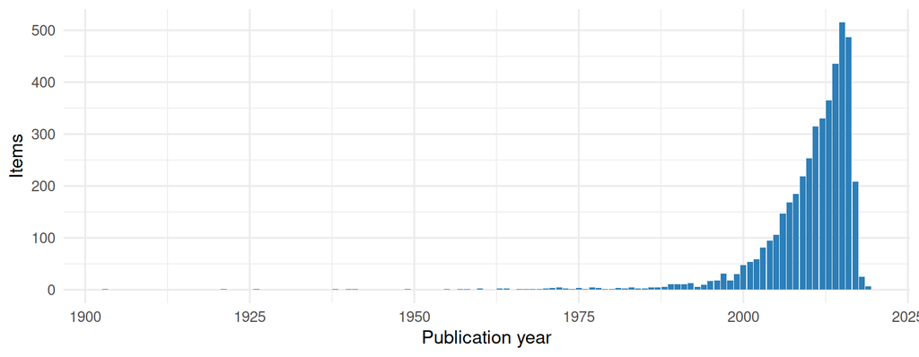

### Types of items

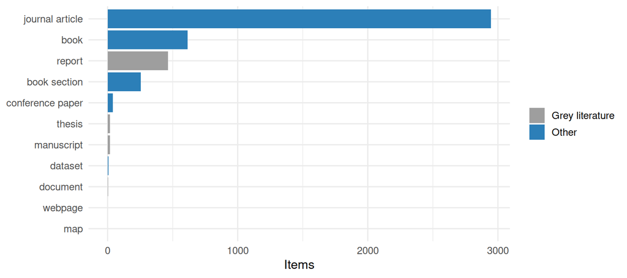

### Open access

Open access status of the publications found in OpenAlex. *Gold* and *diamond*: open in an open access journal; *hybrid*: open in a subscription journal; *green*: an open copy is in a repository; *bronze*: free to read on the publisher’s site; *closed*: not openly available.

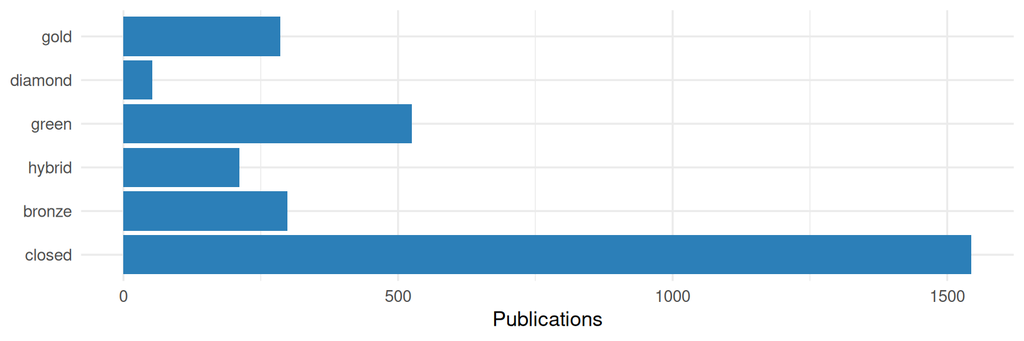

### Most frequent journals

| Journal | Items |
| --- | --- |
| Biological Conservation | 82 |
| Global Change Biology | 81 |
| Science | 64 |
| Nature | 50 |
| PLoS ONE | 47 |
| Biodiversity and Conservation | 45 |
| Ecological Indicators | 44 |
| Journal of Applied Ecology | 43 |
| Proceedings of the National Academy of Sciences | 41 |
| Ecological Economics | 40 |

### Countries of the authors

Number of publications with at least one author from the country, for the publications found in OpenAlex.

| Country | Publications |
| --- | --- |
| United Kingdom | 744 |
| United States | 611 |
| Germany | 541 |
| Sweden | 361 |
| France | 333 |
| Netherlands | 326 |
| Spain | 321 |
| Italy | 267 |
| Switzerland | 238 |
| Australia | 191 |
| Finland | 180 |
| Canada | 174 |
| Belgium | 172 |
| Norway | 167 |
| Denmark | 148 |

## How the checks work

**NoteDetails of the checks**

#### identifiers

##### DOI coverage (`met_id_doi`)

Number and share of items with a valid DOI, and items whose DOI field is filled but contains no valid DOI. DOIs are extracted with `openalexPro::extract_doi()` and lower cased.

##### ISBN coverage (`met_id_isbn`)

Number and share of items with an ISBN, overall and for the item types which should have one (`book`, `bookSection`).

##### ISSN coverage (`met_id_issn`)

Number and share of items with an ISSN, overall and for the item types which should have one (`journalArticle`, `magazineArticle`).

##### ISSN not in the standard form (`met_id_issn_form`)

Items whose ISSN field is not in the standard form: each ISSN as `1234-567X` (with hyphen, capital X), several separated by “,”. The ISSNs are checked with their check digit. If all are valid, the standard form is proposed; otherwise the item is listed with the ISSNs which are not valid.

##### DOIs in the wrong field (`met_id_doi_misplaced`)

Items with an empty DOI field but a DOI in the `Url` or `Extra` field. These DOIs are not used for the OpenAlex lookup and should be moved to the DOI field.

##### DOIs in the wrong form (`met_id_doi_form`)

Items whose DOI field contains a valid DOI, but not as a bare DOI: as a link (`https://doi.org/10.…`), with a prefix (`doi:`, `DOI`), URL-encoded (`%5B` for `[`) or with spaces or other characters around it. Citation styles add the link themselves, so a link in the DOI field appears twice in a bibliography. The bare DOI is the one recognised by `openalexPro::extract_doi()`, keeping its upper and lower case.

##### DOIs which do not exist (`met_id_doi_exists`)

Items whose DOI field contains a DOI in the right form which does not exist at doi.org: usually a typo, a shortened DOI, or a DOI with extra characters at the end (`.`, `;`, a link to supplementary material). Only DOIs which are not found in OpenAlex are checked at doi.org. Where the DOI without the extra characters at the end exists, it is given as suggestion.

##### Items without identifier (`met_id_none`)

Items with none of DOI, ISBN, ISSN or Url. These items can neither be checked against OpenAlex nor easily be retrieved by readers.

##### DOIs found in OpenAlex for items without a DOI (`met_id_candidates`)

For items without a DOI, OpenAlex was searched by title, and by the PubMed ID (line `PMID: …` in Extra), and Crossref by ISBN and title (see [get_doi_candidates()]).

#### metadata

##### Filled fields per item type (`met_meta_fields`)

Percentage of items with a filled field, per item type, for the main fields: Title, Author, Publication Year, Publication Title, Publisher, DOI, ISBN, ISSN, Url, Abstract Note and Language. Not every field is expected for every item type, e.g. reports have no Publication Title.

##### Problematic publication years (`met_meta_year`)

Items whose date is missing (`missing`), from whose date Zotero could not derive a year (`unparseable`), or whose year lies in the future (`future`).

##### Duplicate items (`met_meta_duplicates`)

Items which are in the group more than once, identified by the same DOI, or by the same normalised title (lower case, letters and digits only), publication year and first word of the first author.

##### Language not given as a standard code (`met_meta_language`)

Items whose language is not given as a standard language code, i.e. a two-letter ISO 639-1 code, optionally with a region (`en`, `en-US`), but e.g. as a name (`English`), a three-letter code (`eng`) or in a different spelling (`EN`, `en_us`). Citation styles and other tools only recognise the codes. Where the value is recognised, the standard code is proposed, based on the ISO 639-2 list (R package ISOcodes): codes, three-letter codes and the English names of the languages. Other values, e.g. names in the language itself, several languages or other text, are listed without a proposal.

#### openalex_check

##### Zotero DOIs found in OpenAlex (`met_check_found`)

Valid Zotero DOIs which were / were not found in OpenAlex. A DOI which is not found is either not indexed by OpenAlex or wrong (see `met_id_doi_exists` for DOIs which do not exist). DOIs of works which OpenAlex has under another DOI (e.g. the old and the new DOI of an article) count as found.

##### Retracted works (`met_check_retracted`)

Works flagged as retracted by OpenAlex, with the key of the Zotero item(s) with the same DOI.

##### Wrong DOIs (`met_check_mismatch`)

Items whose DOI points in OpenAlex to a work with a different title or year, which usually means that the wrong DOI is attached to the item. An item is flagged when the title similarity (normalised Levenshtein distance) is below 0.8 or the years differ by more than one. Items with the line `DOI checked: correct` in Extra (someone checked that the DOI is right, e.g. a book chapter with the DOI of the book, or a wrong year in OpenAlex) are not listed.

##### Item type agreement (`met_check_type`)

Zotero item type compared with the OpenAlex work type for items with the same DOI.

##### Missing dates found in OpenAlex (`met_check_date`)

Items without a date whose DOI was found in OpenAlex: the publication date in OpenAlex is proposed. OpenAlex gives 1 January when only the year is known, so such dates are proposed as the year only. Items whose DOI points to a different publication are left out.

##### Empty fields found in OpenAlex (`met_check_fill`)

Journal articles with an empty journal, volume, issue or pages field whose DOI was found in OpenAlex with these details: the values in OpenAlex are proposed. The journal is only taken if the publication is in a journal in OpenAlex (not e.g. a repository). Page ranges which end before they start (e.g. `1260-2`, shortened or wrong) are not proposed. Items whose DOI points to a different publication are left out.

##### Language differs from OpenAlex (`met_check_language`)

Items whose language in Zotero differs from the language of their DOI in OpenAlex. Only the language is compared, not the region (`en-US` and `en` are the same), and only for items whose language is given as a language code (see “Language not given as a language code”). Items without a language are listed under “No language”.

##### OpenAlex ID in the Extra field (`met_check_openalex_id`)

Items whose DOI was found in OpenAlex, compared with the OpenAlex ID noted in their Extra field (a line `OpenAlex: W…`). Items without such a line can get it, which links them to OpenAlex for later checks. Items with a different ID are listed for checking: OpenAlex merges records, and the ID of a merged record redirects to the new one. Items whose DOI points to a different publication are left out.

##### OpenAlex ID in the Extra field not valid (`met_check_extra_id`)

Checks the lines `OpenAlex: …` in the Extra field (looked up by [get_extra_ids()]). A line is not valid if - it is not an OpenAlex work ID (`W` and digits), - the item has several lines with different IDs, - the ID is not in OpenAlex (wrong, or merged into another record), or - the work is a different publication: its DOI is not the DOI of the item, or, for items without DOI, its title is not similar (similarity below 0.8, see [title_similarity()]).

#### profile

##### Publication years (`met_prof_year`)

Number of items per publication year, with cumulative counts. Items without a year are counted as `NA`.

##### Open access status (`met_prof_oa`)

OpenAlex open access status (gold, diamond, green, hybrid, bronze, closed) of the works, overall and per publication year.

##### Top journals (`met_prof_journals`)

The 50 most frequent journals, from the Publication Title in Zotero and the source of the primary location in OpenAlex. Ties at rank 50 are included.

##### Author countries (`met_prof_countries`)

Number of works with at least one author affiliated with an institution in a country, per country (ISO 3166-1 alpha-2 codes from OpenAlex).

##### Item types and grey literature (`met_prof_types`)

Number of items per item type (Zotero) or work type (OpenAlex), and the share of grey literature, i.e. reports, theses, dissertations, web pages, documents, presentations, manuscripts, blog posts and preprints.

##### Languages (`met_prof_language`)

Languages as entered, and normalised to two letter codes (lower case, region removed, English spellings mapped to `en`). Inconsistent codes in the language as entered are a quality issue in themselves.

#### maintenance

##### Group activity (`met_maint_activity`)

Items added per month, and items added / modified in the 30 days before the metrics were calculated.

##### Items without tags (`met_maint_tags`)

Items without manual tags. Automatic tags, e.g. keywords imported from the publisher, are ignored.

IPBES Literature Report 0.7.0 · [source code on GitHub](https://github.com/IPBES-Data/IPBES.LiteratureReport) (© IPBES.LiteratureReport authors, [MIT licence](https://opensource.org/license/mit)) · reports and data on this website: [CC0 1.0](https://creativecommons.org/publicdomain/zero/1.0/) (no rights reserved)